# D-penicillamine in Primary Biliary Cholangitis

A survival and competing-risks re-analysis of the Mayo Clinic PBC trial

Author

Your Name

Published

September 2026

Abstract

The Mayo Clinic randomised trial of D-penicillamine in primary biliary cholangitis (PBC) is one of the classic datasets in survival analysis. This report re-analyses it end-to-end with an emphasis on two questions that a single log-rank test cannot answer: does the treatment delay the first unfavourable event, and once death and liver transplant are separated as distinct outcomes, does the treatment change the cause-specific risk of death? The report is fully reproducible from `data/pbc.csv`.

# 1 Background and data

Primary biliary cholangitis (PBC) is a chronic, progressive cholestatic liver disease. The Mayo Clinic trial randomised patients to D-penicillamine, an immunomodulator, or placebo, with the working hypothesis that slowing disease progression would delay death or the need for liver transplantation. The public dataset (`survival::pbc`) contains laboratory markers, clinical signs, and follow-up times for 418 patients.

Of these, 106 were not randomised (an observational follow-up group) and are excluded from every analysis below. The analysis cohort is therefore **312 randomised patients**.

The endpoint variable is worth pausing on. The raw `status` field has three levels:

- `0` censored,
- `1` transplant,
- `2` death.

Two analyses are possible from this one field, and they answer different questions. Collapsing transplant and death into a single “composite” event asks whether treatment delays *the first unfavourable event of any kind*. Keeping them apart asks whether treatment changes the *risk of death specifically*, treating transplant as a competing event that removes a patient from the risk set for death. Because a transplant is not obviously a bad outcome, the two analyses can disagree in direction, and that disagreement is itself the interesting finding. This report runs both.

```r
cohort <- prepare_cohort()
dim(cohort)
```

```
[1] 312  20
```

# 2 Baseline characteristics

Table 1 summarises the cohort by arm. Continuous variables that are roughly symmetric (age, albumin, cholesterol) are reported as mean (SD) and tested with t-tests; right-skewed laboratory markers (bilirubin, copper, alkaline phosphatase, AST, triglycerides, platelets, prothrombin time) are reported as median [IQR] and tested with Wilcoxon rank-sum tests. A Benjamini–Hochberg q-value is added alongside each p-value because a table of this size performs many simultaneous comparisons.

```r
make_baseline_table(cohort) |>
  as_gt()
```

Table 1: Baseline characteristics by treatment arm

| **Characteristic** | **Overall** N = 312<sup>1</sup> | **D-penicillamine** N = 158<sup>1</sup> | **Placebo** N = 154<sup>1</sup> | **p-value**<sup>2</sup> | **q-value**<sup>3</sup> |
| --- | --- | --- | --- | --- | --- |
| Age (years) | 50.02 (10.58) | 51.42 (11.01) | 48.58 (9.96) | 0.018 | 0.281 |
| sex |  |  |  | 0.326 | 0.885 |
| Male | 36 (12%) | 21 (13%) | 15 (9.7%) |  |  |
| Female | 276 (88%) | 137 (87%) | 139 (90%) |  |  |
| ascites |  |  |  | 0.433 | 0.885 |
| No | 288 (92%) | 144 (91%) | 144 (94%) |  |  |
| Yes | 24 (7.7%) | 14 (8.9%) | 10 (6.5%) |  |  |
| hepato |  |  |  | 0.069 | 0.552 |
| No | 152 (49%) | 85 (54%) | 67 (44%) |  |  |
| Yes | 160 (51%) | 73 (46%) | 87 (56%) |  |  |
| spiders |  |  |  | 0.885 | 0.885 |
| No | 222 (71%) | 113 (72%) | 109 (71%) |  |  |
| Yes | 90 (29%) | 45 (28%) | 45 (29%) |  |  |
| edema |  |  |  | 0.877 | 0.885 |
| No edema | 263 (84%) | 132 (84%) | 131 (85%) |  |  |
| Responsive to diuretics | 29 (9.3%) | 16 (10%) | 13 (8.4%) |  |  |
| Refractory edema | 20 (6.4%) | 10 (6.3%) | 10 (6.5%) |  |  |
| Serum Bilirubin (mg/dl) | 1.35 [0.80, 3.45] | 1.40 [0.80, 3.20] | 1.30 [0.70, 3.60] | 0.842 | 0.885 |
| chol | 369.51 (231.94) | 365.01 (209.54) | 373.88 (252.48) | 0.747 | 0.885 |
| Missing (N/A) | 28 | 18 | 10 |  |  |
| albumin | 3.52 (0.42) | 3.52 (0.44) | 3.52 (0.40) | 0.874 | 0.885 |
| copper | 73.00 [41.00, 123.00] | 73.00 [40.00, 121.00] | 73.00 [43.00, 139.00] | 0.718 | 0.885 |
| Missing (N/A) | 2 | 1 | 1 |  |  |
| Alkaline Phosphatase (U/L) | 1,259.00 [867.00, 1,985.00] | 1,214.50 [836.00, 2,039.00] | 1,283.00 [918.00, 1,960.00] | 0.812 | 0.885 |
| ast | 114.70 [80.60, 151.90] | 111.60 [75.95, 151.90] | 117.40 [83.70, 151.90] | 0.459 | 0.885 |
| trig | 108.00 [84.00, 151.00] | 106.00 [84.00, 146.00] | 113.00 [84.00, 156.00] | 0.370 | 0.885 |
| Missing (N/A) | 30 | 19 | 11 |  |  |
| platelet | 257.00 [199.50, 323.00] | 255.00 [189.00, 323.00] | 259.50 [206.50, 323.00] | 0.455 | 0.885 |
| Missing (N/A) | 4 | 2 | 2 |  |  |
| Prothrombin Time (s) | 10.60 [10.00, 11.10] | 10.60 [10.00, 11.00] | 10.60 [10.00, 11.40] | 0.588 | 0.885 |
| stage |  |  |  | 0.201 | 0.885 |
| Stage 1 | 16 (5.1%) | 12 (7.6%) | 4 (2.6%) |  |  |
| Stage 2 | 67 (21%) | 35 (22%) | 32 (21%) |  |  |
| Stage 3 | 120 (38%) | 56 (35%) | 64 (42%) |  |  |
| Stage 4 | 109 (35%) | 55 (35%) | 54 (35%) |  |  |

<sup>1</sup> Mean (SD); n (%); Median [Q1, Q3]  
<sup>2</sup> Welch Two Sample t-test; Pearson’s Chi-squared test; Wilcoxon rank sum test  
<sup>3</sup> False discovery rate correction for multiple testing

# 3 Composite endpoint: transplant-free survival

The first analysis treats transplant or death as a single event.

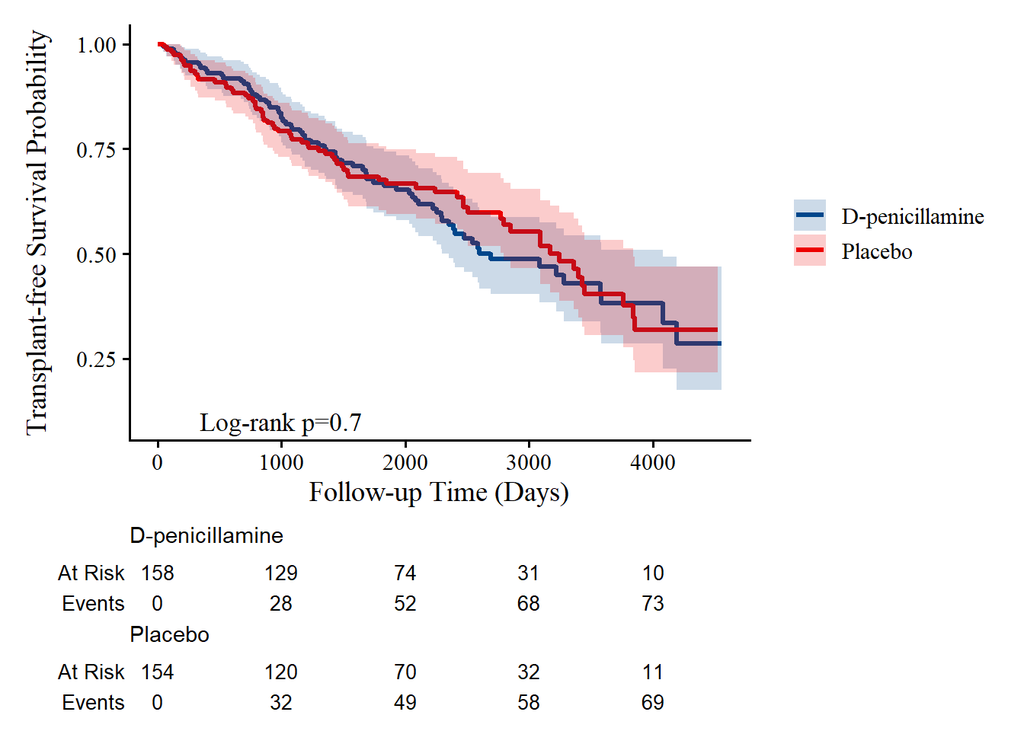

Figure 1: Kaplan-Meier estimates of transplant-free survival by treatment arm.

```r
make_km_plot(prepare_s1()) |>
  print()
save_figure(make_km_plot(prepare_s1()), "km_composite.png", width = 9, height = 6)
```

```r
logrank_fit <- run_logrank(prepare_s1())
logrank_p   <- logrank_fit$pvalue
logrank_fit
```

```
Call:
survival::survdiff(formula = survival::Surv(time, status) ~ trt,
    data = dat)

                      N Observed Expected (O-E)^2/E (O-E)^2/V
trt=D-penicillamine 158       75     72.9    0.0595     0.121
trt=Placebo         154       69     71.1    0.0611     0.121

 Chisq= 0.1  on 1 degrees of freedom, p= 0.7
```

The two curves are nearly superimposed. The log-rank test gives p = 0.728, so there is no evidence that D-penicillamine delays the composite endpoint of transplant or death. Because the arms were balanced apart from the nominal age difference noted above, and because the models below will adjust for age anyway, this reads as a genuine null rather than a confounded one.

# 4 Competing risks: cumulative incidence of death

The composite analysis above treats transplant and death as interchangeable. They are not. If D-penicillamine improved access to transplantation without changing the underlying death hazard, the composite analysis would credit it with a benefit it does not have — or conversely, a treatment that delays transplant but not death would look worse on the composite scale than it is.

Treating death as the event of interest and transplant as a competing event gives the cause-specific picture.

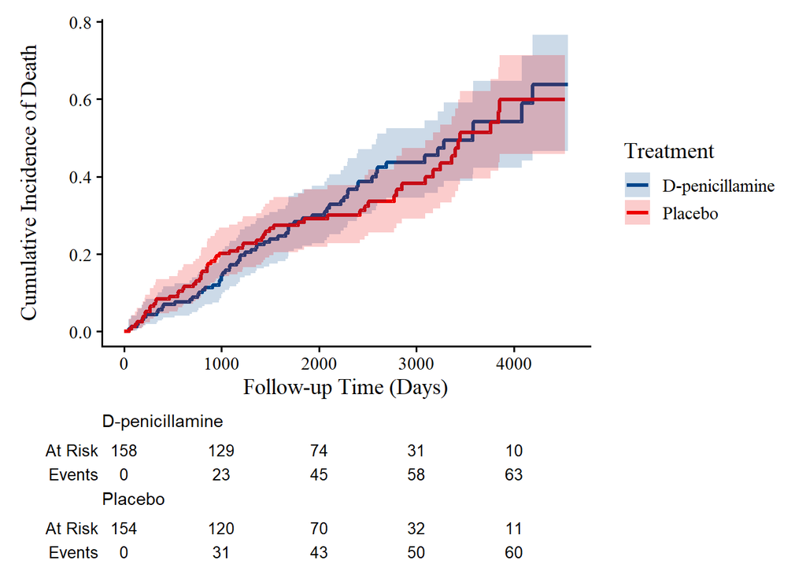

Figure 2: Cumulative incidence of death, with transplant treated as a competing event.

```r
make_cuminc_plot(prepare_s2()) |>
  print()
save_figure(make_cuminc_plot(prepare_s2()), "cuminc_death.png", width = 9, height = 6)
```

```r
make_cuminc_table(prepare_s2()) |>
  as_gt()
```

Table 2: 5-year cumulative incidence of death and Gray’s test

| **Characteristic** | **N** | **5-year cumulative incidence** | **p-value**<sup>1</sup> |
| --- | --- | --- | --- |
| trt | 312 |  | 0.796 |
| D-penicillamine |  | 28% (21%, 36%) |  |
| Placebo |  | 28% (21%, 36%) |  |

<sup>1</sup> Gray’s Test

The curves again track closely, and Gray’s test — the competing-risks analogue of the log-rank test, which must be used here rather than a standard log-rank — confirms no significant difference in the 5-year cumulative incidence of death. Separating the endpoints does not change the conclusion: D-penicillamine does not affect mortality in this trial.

# 5 Cox proportional hazards models

We now move from group-level curves to covariate-adjusted hazard ratios. The unadjusted model first, then adjustment for the classical PBC prognostic factors: age, bilirubin, and prothrombin time. These follow the Mayo risk score for PBC and are the covariates a reviewer would expect to see.

```r
format_cox_table(
  fit_cox_unadjusted(prepare_s1()),
  caption = "Unadjusted Cox regression (composite endpoint)"
) |> as_gt()
```

Table 3: Unadjusted Cox model for transplant-free survival

Unadjusted Cox regression (composite endpoint)

| **Characteristic** | **HR** | **95% CI** | **p-value** |
| --- | --- | --- | --- |
| trt |  |  | 0.728 |
| D-penicillamine | — | — |  |
| Placebo | 0.94 | 0.68, 1.31 |  |

Abbreviations: CI = Confidence Interval, HR = Hazard Ratio

```r
format_cox_table(
  fit_cox_multi_linear(prepare_s1()),
  caption = "Multivariable Cox regression, linear covariates"
) |> as_gt()
```

Table 4: Multivariable Cox model with linear covariates

Multivariable Cox regression, linear covariates

| **Characteristic** | **HR** | **95% CI** | **p-value** |
| --- | --- | --- | --- |
| trt |  |  | 0.395 |
| D-penicillamine | — | — |  |
| Placebo | 0.86 | 0.62, 1.21 |  |
| age | 1.02 | 1.00, 1.04 | 0.026 |
| bili | 1.14 | 1.12, 1.17 | <0.001 |
| protime | 1.28 | 1.13, 1.46 | <0.001 |

Abbreviations: CI = Confidence Interval, HR = Hazard Ratio

Treatment is not significant in either model, consistent with the log-rank result. Among the covariates, bilirubin and prothrombin time are the substantive prognostic markers, which matches the clinical literature.

## 5.1 Checking the proportional hazards assumption

A Cox model reports one hazard ratio per covariate, which is only meaningful if that ratio is constant over follow-up. The Schoenfeld residual test checks this assumption; a significant p-value means the HR drifts over time and should not be reported as a single number.

```r
ph_linear <- ph_test(fit_cox_multi_linear(prepare_s1()))
ph_linear
```

```
           chisq df      p
trt      0.00896  1 0.9246
age      3.48305  1 0.0620
bili     7.69013  1 0.0056
protime  5.35633  1 0.0206
GLOBAL  17.57699  4 0.0015
```

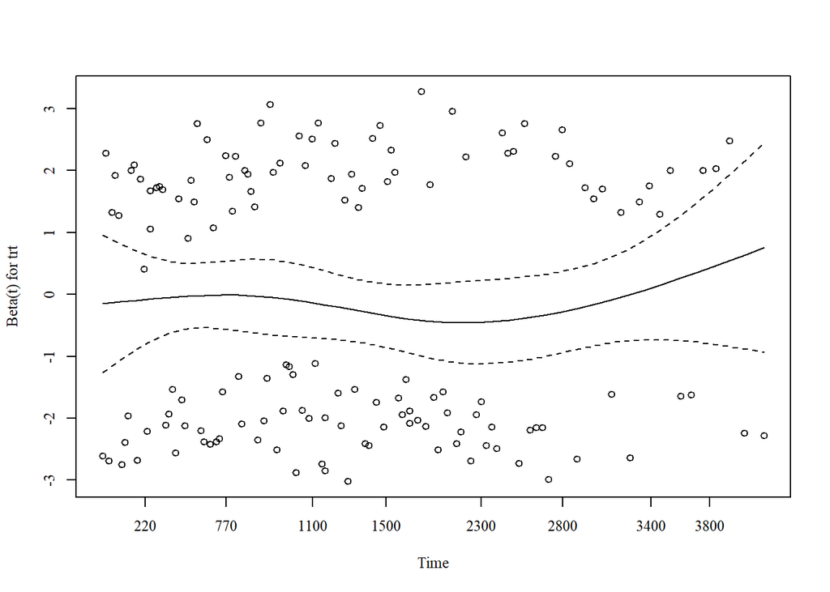

Figure 3: Schoenfeld residuals for the linear-covariate model. A non-horizontal trend indicates the hazard ratio changes over time.

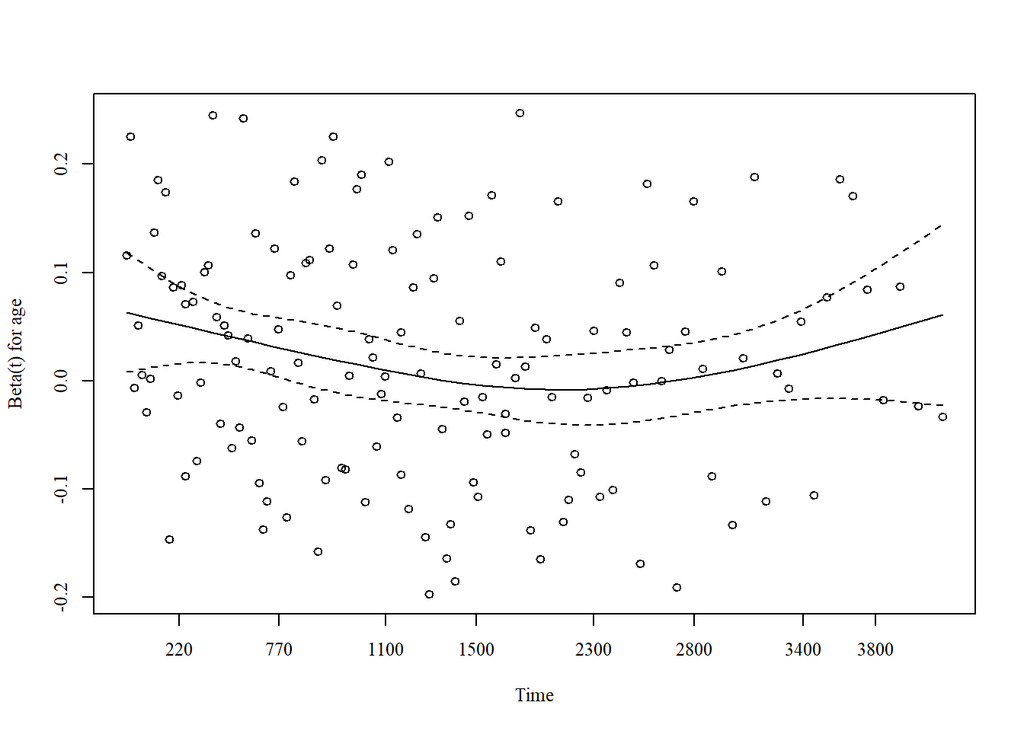

Figure 4: Schoenfeld residuals for the linear-covariate model. A non-horizontal trend indicates the hazard ratio changes over time.

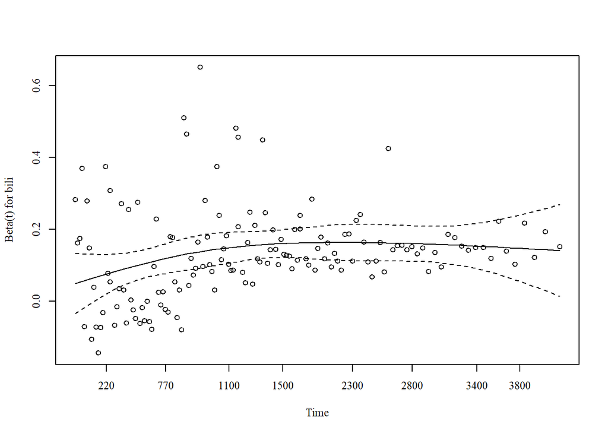

Figure 5: Schoenfeld residuals for the linear-covariate model. A non-horizontal trend indicates the hazard ratio changes over time.

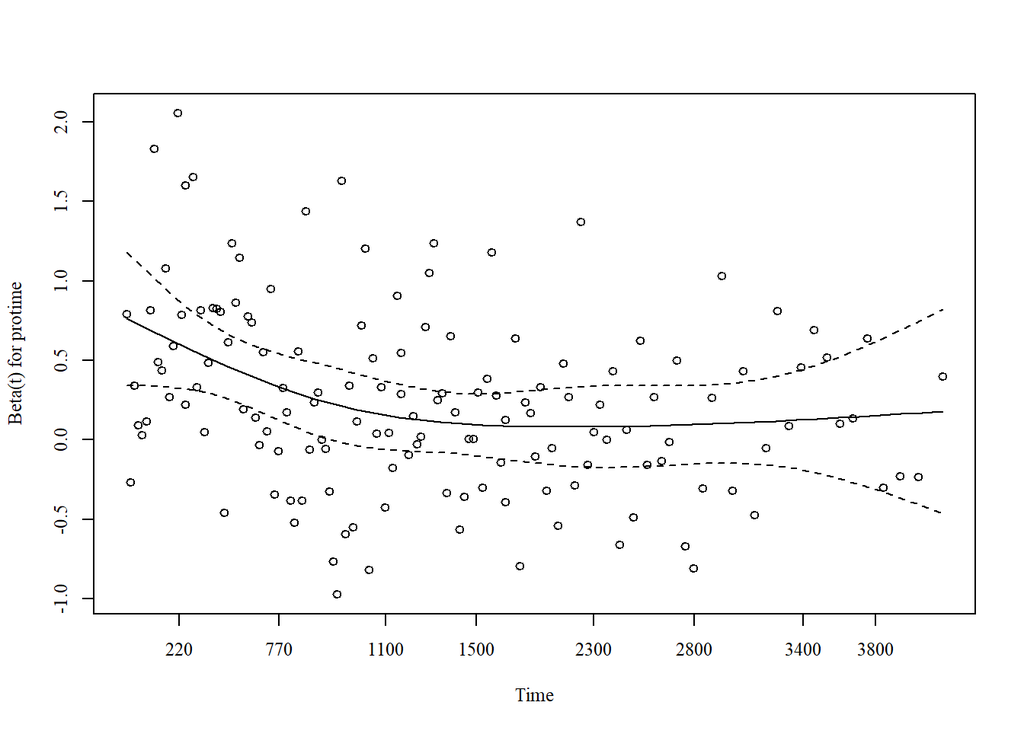

Figure 6: Schoenfeld residuals for the linear-covariate model. A non-horizontal trend indicates the hazard ratio changes over time.

```r
ph_plot(ph_linear, base_size = 11)
```

```r
# Build the log-transformed variant inside the analysis so the transformation
# is visible in the report rather than buried in a helper.
s1_log <- prepare_s1() |>
  mutate(log_bili = log(bili), log_protime = log(protime)) |>
  add_protime_cat()

cox_log <- coxph(
  Surv(time, status) ~ trt + age + log(bili) + log(protime),
  data = s1_log
)
ph_test(cox_log)
```

```
              chisq df     p
trt          0.0226  1 0.880
age          2.9758  1 0.085
log(bili)    0.2619  1 0.609
log(protime) 5.6917  1 0.017
GLOBAL       8.2763  4 0.082
```

Log-transforming bilirubin resolves its violation, but prothrombin time still fails. When a covariate cannot be made to satisfy proportional hazards, the correct move is to **stratify** on it rather than force a single HR: the model then estimates the treatment effect *within* strata of prothrombin time and makes no assumption about its shape over time.

The cost is that a stratified Cox model cannot estimate an HR for the stratification variable itself. Since prothrombin time is a strong prognostic marker but not our exposure of interest, this is an acceptable trade.

```r
s1_strat <- add_protime_cat(prepare_s1())
cox_strat <- fit_cox_multi_stratified(s1_strat)
ph_strat  <- ph_test(cox_strat)

format_cox_table(
  cox_strat,
  caption = "Multivariable Cox regression, stratified by prolonged prothrombin time"
) |> as_gt()
```

Table 5: Multivariable Cox model stratified by prothrombin time

Multivariable Cox regression, stratified by prolonged prothrombin time

| **Characteristic** | **HR** | **95% CI** | **p-value** |
| --- | --- | --- | --- |
| trt |  |  | 0.780 |
| D-penicillamine | — | — |  |
| Placebo | 1.05 | 0.75, 1.47 |  |
| age | 1.02 | 1.01, 1.04 | 0.005 |
| Log(Serum Bilirubin) | 2.57 | 2.14, 3.08 | <0.001 |

Abbreviations: CI = Confidence Interval, HR = Hazard Ratio

```r
ph_strat
```

```
            chisq df    p
trt       0.00113  1 0.97
age       2.24191  1 0.13
log(bili) 1.67332  1 0.20
GLOBAL    4.10217  3 0.25
```

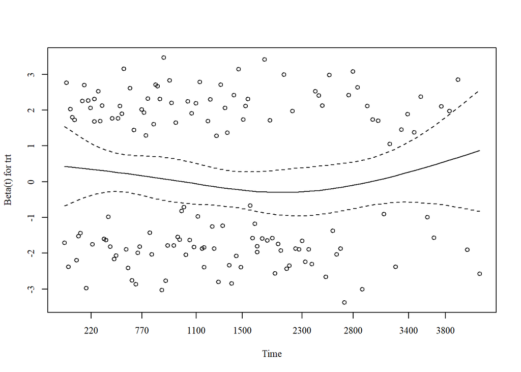

Figure 7: Schoenfeld residuals after stratification on prothrombin time. Skipping the slope test for the stratification factor is expected.

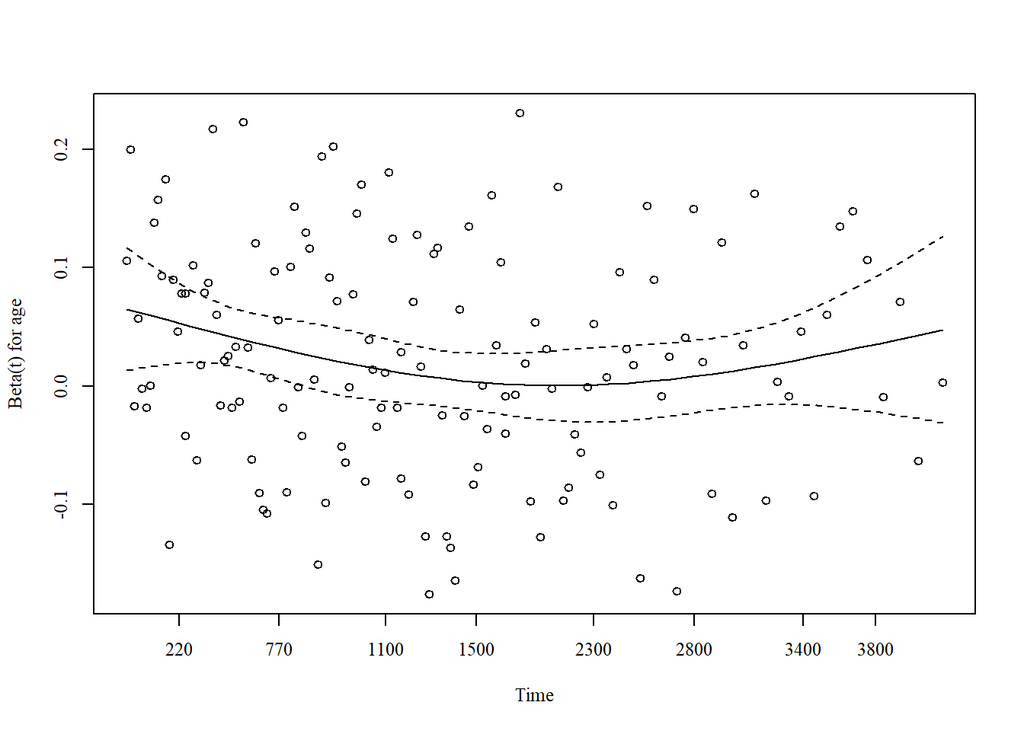

Figure 8: Schoenfeld residuals after stratification on prothrombin time. Skipping the slope test for the stratification factor is expected.

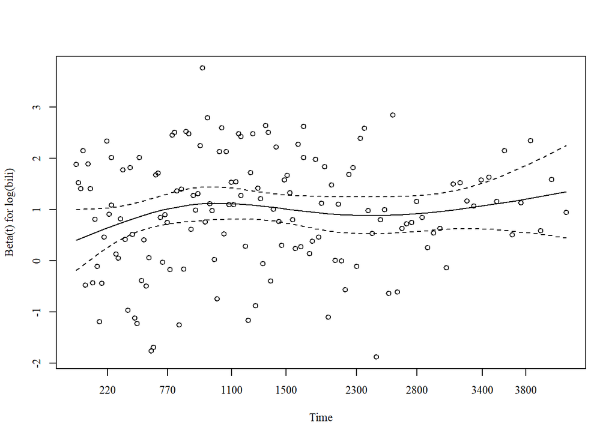

Figure 9: Schoenfeld residuals after stratification on prothrombin time. Skipping the slope test for the stratification factor is expected.

```r
ph_plot(ph_strat, base_size = 11)
```

The stratification clears the remaining violation, and the substantive conclusion is unchanged: the treatment HR stays close to 1 and non-significant, while age and log-bilirubin carry the prognostic signal.

# 6 Fine-Gray subdistribution model

The final piece applies the same covariate structure to the competing-risks endpoint. A standard Cox model cannot be used here: once a patient receives a transplant they are no longer at risk of death in the usual sense, but treating transplant as ordinary censoring assumes transplant and death are independent, which is implausible. The Fine-Gray subdistribution hazard model keeps transplanted patients in the risk set with declining weight, giving subdistribution hazard ratios (sHR) that map directly onto the cumulative incidence curves from earlier.

```r
fg_fit <- fit_fine_gray(prepare_s2())
format_cox_table(
  fg_fit,
  caption = "Fine-Gray subdistribution model, stratified by prothrombin time",
  header  = "**sHR**"
) |> as_gt()
```

Table 6: Fine-Gray subdistribution model for death, transplant as competing event

| **Characteristic** | **sHR** | **95% CI** | **p-value** |
| --- | --- | --- | --- |
| trt |  |  | 0.459 |
| D-penicillamine | — | — |  |
| Placebo | 1.15 | 0.80, 1.65 |  |
| age | 1.04 | 1.02, 1.06 | <0.001 |
| Log(Serum Bilirubin) | 2.47 | 2.03, 3.01 | <0.001 |
| strata(protime_cat) |  |  | <0.001 |
| Normal (<11s) | — | — |  |
| Prolonged (>=11s) | 2.16 | 1.49, 3.11 |  |

Abbreviations: CI = Confidence Interval, HR = Hazard Ratio

```r
# crr() has no cox.zph method, so the equivalent weighted-Cox representation is
# used purely to test the proportional subdistribution hazards assumption.
fg_cox <- fit_fine_gray_cox(prepare_s2())
ph_test(fg_cox)
```

```
            chisq df    p
trt       0.22387  1 0.64
age       0.12870  1 0.72
log(bili) 0.00878  1 0.93
GLOBAL    0.46133  3 0.93
```

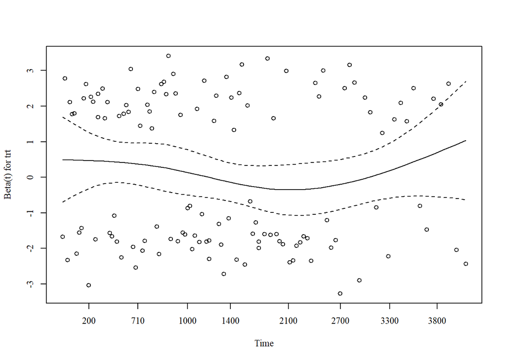

Figure 10: Schoenfeld residuals for the Fine-Gray weighted-Cox representation.

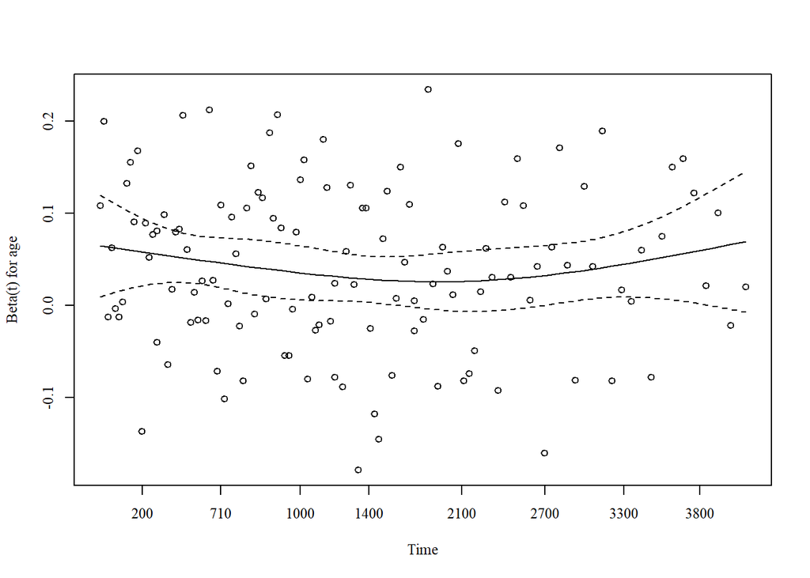

Figure 11: Schoenfeld residuals for the Fine-Gray weighted-Cox representation.

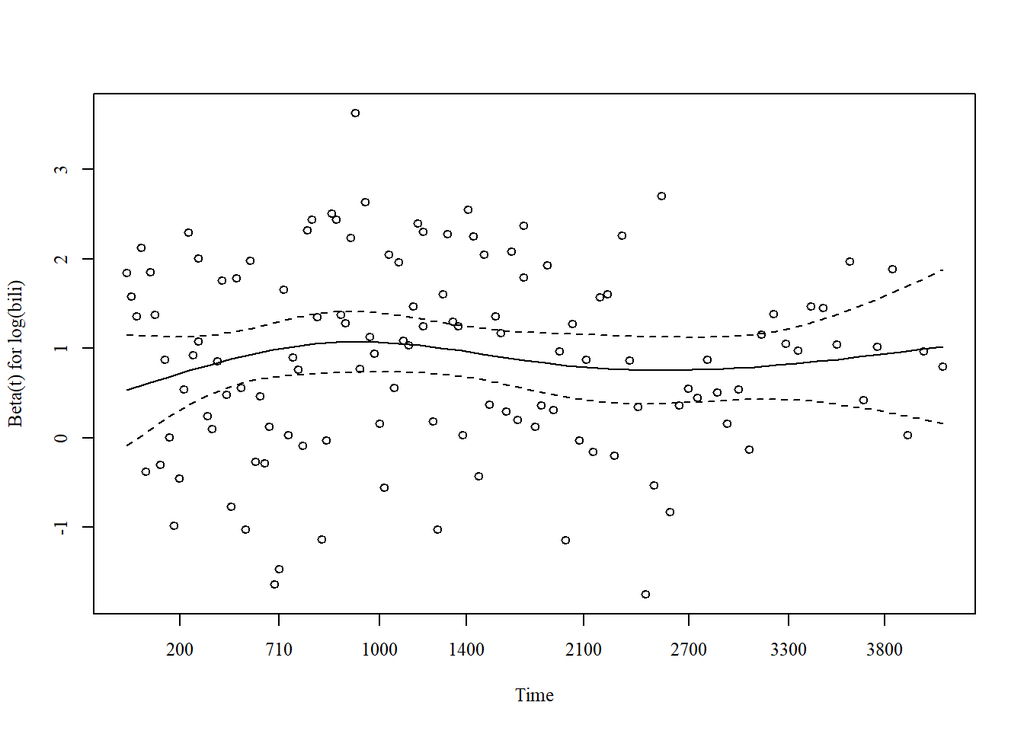

Figure 12: Schoenfeld residuals for the Fine-Gray weighted-Cox representation.

```r
ph_plot(ph_test(fg_cox), base_size = 11)
```

The subdistribution model agrees with everything before it: no treatment effect on the risk of death, with age and bilirubin again doing the prognostic work. The point of including it is not to overturn the earlier result but to show that the null survives when the endpoint is handled the most defensible way available.

# 7 Discussion

Three analyses of the same endpoint — a Kaplan-Meier composite, a cumulative incidence under competing risks, and a Fine-Gray subdistribution model — reach the same conclusion from different angles: in the Mayo PBC trial, D-penicillamine did not delay transplant-free survival, did not reduce the cause-specific risk of death, and did not do so after adjustment for the established prognostic factors. The treatment effect is null, and it is a null that holds up under the modelling choices a reviewer would challenge.

## 7.1 Limitations

The trial is small and the follow-up is long, so the covariate-adjusted estimates carry wide confidence intervals. Prothrombin time is dichotomised at the upper limit of normal (11 s) to enable stratification; this cut point is clinically motivated but does not use the full information in the marker, and a continuous spline or time-varying coefficient would be a reasonable extension. Finally, this is a re-analysis of a public dataset for methodological illustration, not a new clinical claim.